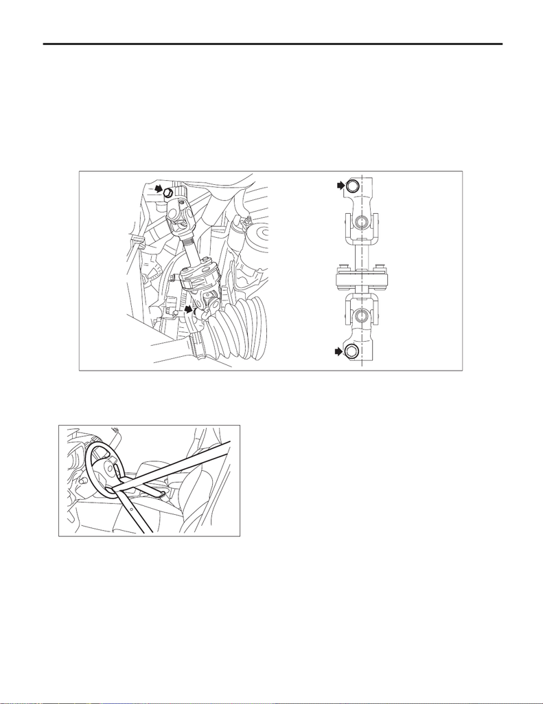

PS-21

Universal Joint

POWER ASSISTED SYSTEM (POWER STEERING)

4. Universal Joint

A: REMOVAL

1) Remove the universal joint assembly - steering.

(1) Place alignment marks on the universal joint assembly - steering.

NOTE:

Place alignment marks on the following positions.

• Between the column assembly - steering and the universal joint assembly - steering

• Between the steering gearbox assembly and the universal joint assembly - steering

(2) Remove the bolt, and remove the universal joint assembly - steering.

2) Set the steering column and the driver’s seat to the neutral position.

CAUTION:

Always place the tilt lever to the lock position after the steering column is adjusted.

3) Prevent the steering wheel from turning using the seat belt.

PS-01318

PS-01711

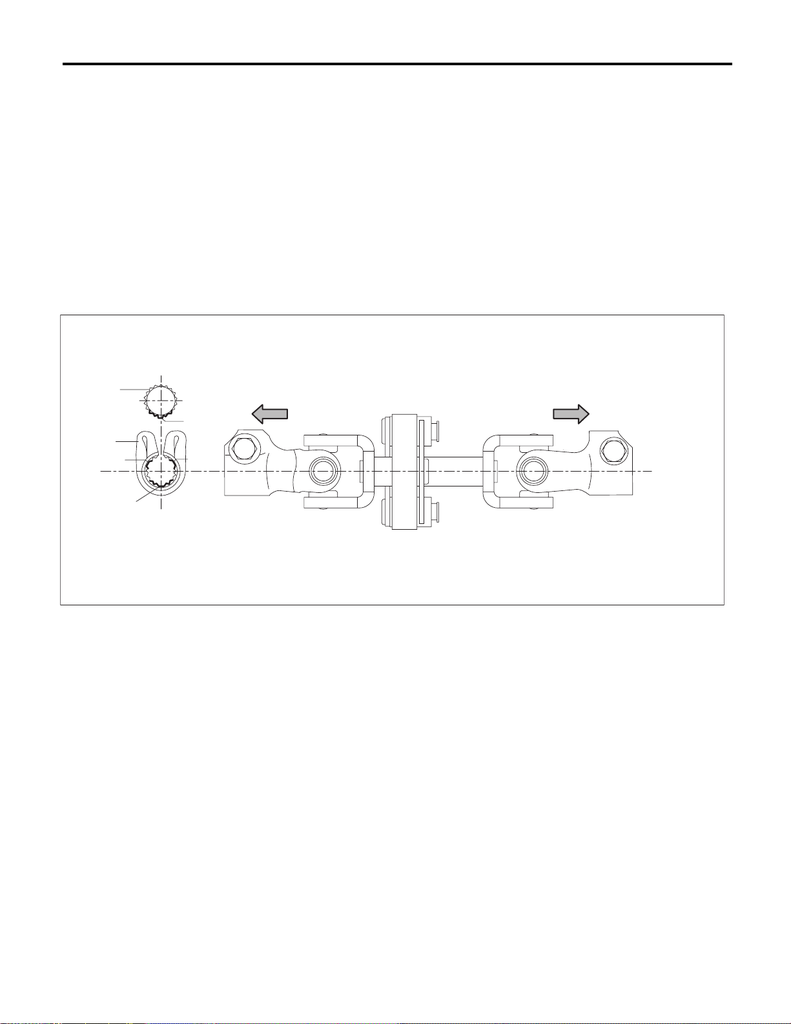

PS-22

Universal Joint

POWER ASSISTED SYSTEM (POWER STEERING)

B: INSTALLATION

1) Before installation, check the universal joint assembly - steering. <Ref. to PS-23, INSPECTION, Universal

Joint.>

2) Unfasten the seat belt and make the steering wheel turn freely.

3) Install the universal joint assembly - steering to the column shaft.

CAUTION:

• Be sure to align the protrusion section (a) of the column shaft side with the cutout (a) of the serra-

tion. If another cutout portions (d) are used for alignment, the bolt of the universal joint assembly -

steering cannot be assembled.

• Be sure to follow the tightening order and tightening torque of the universal joint assembly - steer-

ing to avoid the steering effort from becoming heavy.

(1) Match the alignment marks that have been marked when removing with the column shaft (c) and the

cutout portion (a) at the serrations of the yoke (b).

(2) Connect the universal joint assembly - steering with the column shaft.

(3) Install the universal joint assembly - steering to the serrations of the gearbox assembly by matching

the alignment marks that have been marked when removing.

(4) Tighten the bolts on the gearbox side first, and then the column shaft side.

Tightening torque:

24 N·m (2.4 kgf-m, 17.7 ft-lb)

Clearance:

Universal joint assembly - steering coupling to adjacent parts: 15 mm (0.59 in) or more

(A) Column shaft side (B) Gearbox side

(a)

(b)

(c)

(a)

(A)

(B)

(d)

(d)

PS-01377

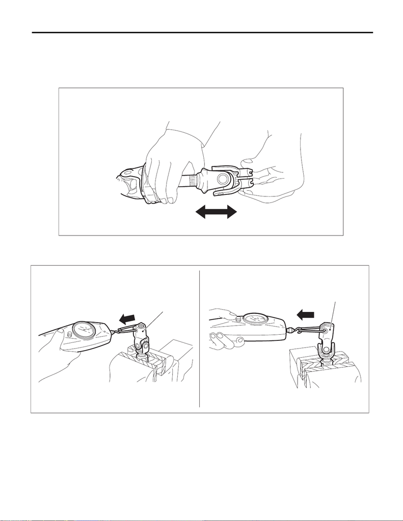

PS-23

Universal Joint

POWER ASSISTED SYSTEM (POWER STEERING)

C: INSPECTION

Check for wear, damage or any other faults.

1) Check the universal joint assembly - steering for excessive looseness.

Service limit:

Play of the universal joint assembly - steering: 0 mm (0 in)

2) Measure the swing torque of the universal joint assembly - steering.

(1) Place the universal joint assembly - steering between wooden blocks and fix it on a vise.

(2) With the yoke (a) of gearbox side facing up, measure the swing torque in two directions.

Service limit:

Maximum load: 3.8 N (0.39 kgf, 0.86 lbf) or less

PS-01279

PS-01136

(a)

(a)

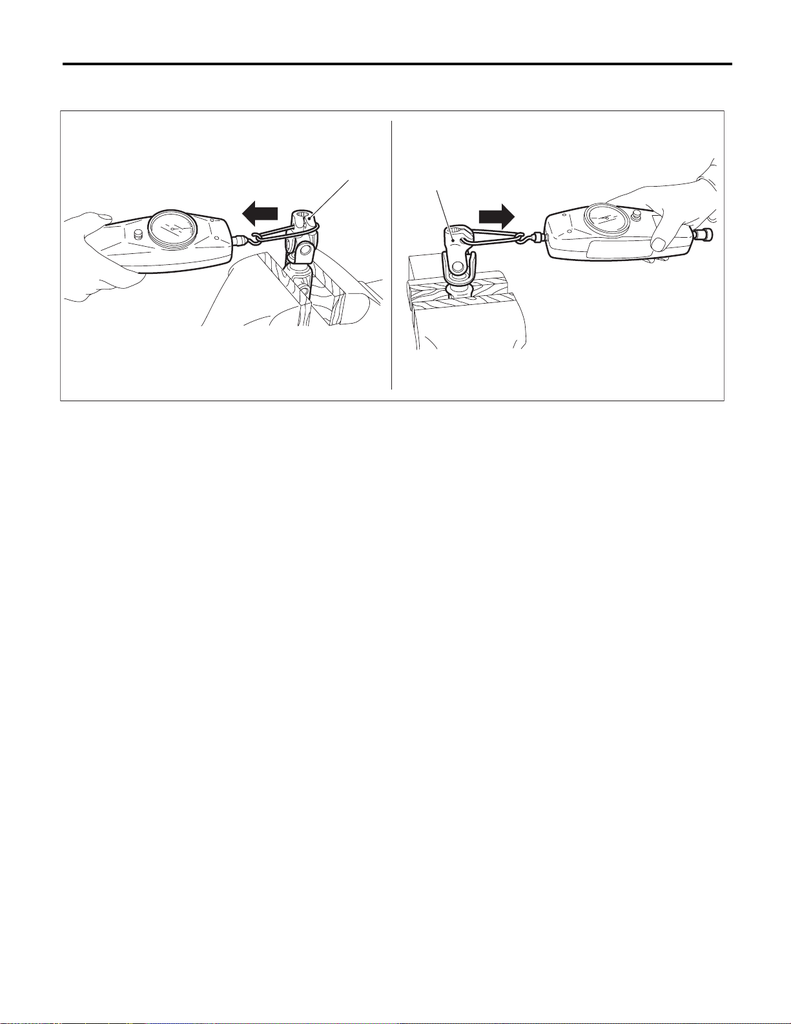

PS-24

Universal Joint

POWER ASSISTED SYSTEM (POWER STEERING)

(3) With the yoke (b) of the column assembly - steering side facing up, measure the swing torque in two

directions.

Service limit:

Maximum load: 7.3 N (0.74 kgf, 1.64 lbf) or less

(4) Replace as necessary, if it is found defective.

PS-01137

(b)

(b)